# 950 Final Project

## 6.15 zipcode

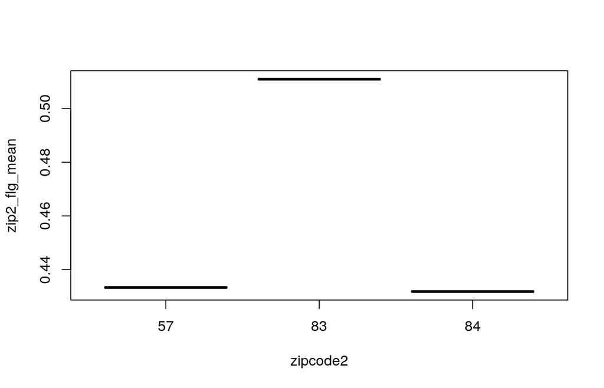

```r
dt[,':=' (zipcode2 = as.factor(str_sub(address_zip,1,2)),
          zipcode3 = as.factor(str_sub(address_zip,1,3)))]

# plot(dt$zipcode2~dt$flgGood)
# plot(dt$zipcode3~dt$flgGood)

dt%>%group_by(zipcode2)%>%
  summarise(zip2_flg_mean=mean(flgGood)) %>% plot()
```

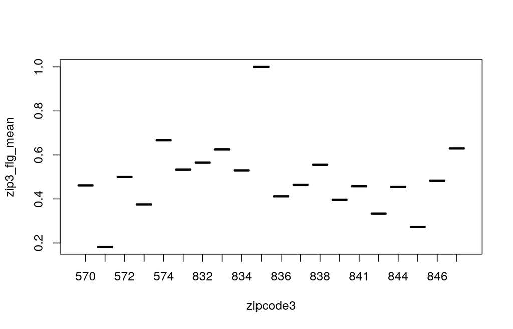

```r
dt%>%group_by(zipcode3)%>%
  summarise(zip3_flg_mean=mean(flgGood)) %>% plot()
```

So location matters.

## 6.16 bank routing number

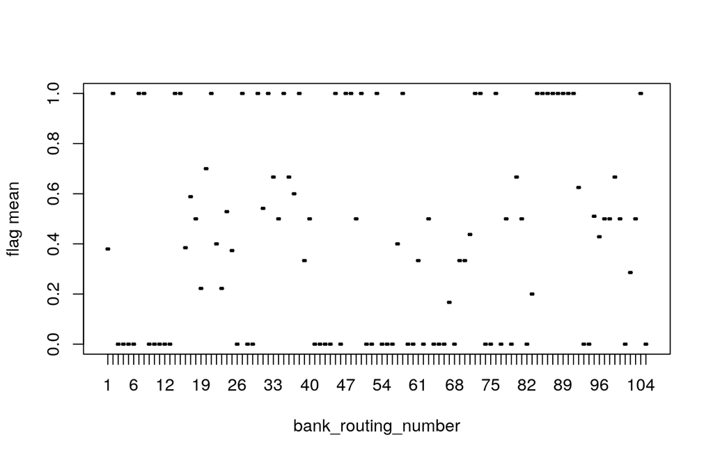

```r
dt[, ':='(bank_routing_number = as.character(bank_routing_number))]
dt[, ':='(bank_routing_number_edit = nchar(bank_routing_number)==9)]
dt[, ':='(bank_routing_number_edit = facCat2(as.integer(bank_routing_number)*bank_routing_number_edit))]

tmp <- dt %>% group_by(bank_routing_number_edit) %>%
  summarise(routing_number_flgMean = mean(flgGood))

plot(tmp$bank_routing_number_edit,tmp$routing_number_flgMean, xlab = 'bank_routing_number', ylab = 'flag mean')
```

```r
# glimpse(dt)
```

## 6.17 email domain

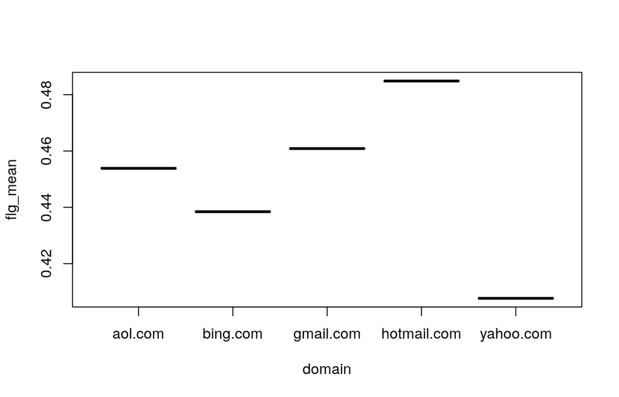

```r
dt%>%group_by(domain)%>%
  summarise(flg_mean=mean(flgGood)) %>% plot()
```

# 7 Preprocessing–continued

In this part, I will tackle problems found in the above section and factorize categorical/ordinal variables.

```r
train <- dt
```

- categorical/ordinal

```r
catNames <- c('home_phone_type','other_phone_type','how_use_money','address_zip','bank_routing_number','domain')
train <- fact_Cat(data.frame(train),catNames)
catNames <- c('email_duration','residence_duration','bank_account_duration','payment_frequency')
train <- fact2int(data.frame(train),catNames)
train <- fact_Cat(data.frame(train),catNames)
catNames <- c('bank_routing_number_edit','zipcode2','zipcode3')
train <- fact_Cat(data.frame(train),catNames)
# catNames <- c('how_use_money','domain','zipcode2','zipcode3')
# train <- OneHot(as.data.frame(train), catNames)
# train <- data.table(train)
```

- reduce colinearity: drop covariates/add indicators/averaging

```r
train$payment_amount_approved <- NULL
train[,raw_FICO := (raw_FICO_retail + raw_FICO_telecom)/2]
train[, flg_loan_duration :=  (loan_duration==duration_approved)*as.integer(1)]
train[, flg_amount_requested := (amount_requested == amount_approved)*as.integer(1)]
train$duration_approved <- train$amount_approved <-  NULL
```

- drop useless covariates: emails, address_zip, monthly_rent_amount, monthly_income_amount

```r
train$bank_routing_number_edit <- NULL # train$bank_routing_number <- NULL
train$address_zip <- NULL
train$monthly_rent_amount <- NULL # monthly_rent_amount contradict with rent-or-own
train$monthly_income_amount <- NULL
```

- generating new covariates: age, zipcode_2,zipcode_3, etc.
- create a 10-fold cross validation set

```r
# validation set
set.seed(1988);nfold=10
train$rand<-runif(nrow(train))
train$validationGroup <- 1
for (i in 1:nfold){
  train$validationGroup<-with(train,ifelse(rand>(i-1)/nfold & rand<i/nfold,i,validationGroup))
};train$rand <- NULL

train <- data.frame(train)
catNames <- list('residence_rent_or_own','loan_duration','domain',
  'email_duration','residence_duration','bank_account_duration','payment_frequency',
  'home_phone_type','how_use_money','zipcode2','zipcode3','month',
  'flg_loan_duration','flg_amount_requested')
for (set in catNames){
  var <- paste(c('baye^',set),collapse="|")
  tmp <- bayesEncoding(d=train,y='flgGood',vars=set, group='validationGroup')
  train[[var]] = tmp$mean_flgGood
}
catNames <- list(c('payment_frequency','zipcode3'))
for (set in catNames){
  var <- paste(c('baye^',set),collapse="|")
  tmp <- bayesEncoding(d=train,y='flgGood',vars=set, group='validationGroup')
  train[[var]] = tmp$mean_flgGood
}
train <- data.table(train)
head(train)
```

```
##    customer_id amount_requested residence_rent_or_own
## 1:  9ece67d6c5              500                     1
## 2:  5c2c402094              500                     1
## 3:  e6254cad30              400                     1
## 4:  49fb42f51d              500                     0
## 5:  195fbe5739              300                     1
## 6:  b5286ff5b4              400                     0
##    bank_account_direct_deposit loan_duration num_payments payment_amount
## 1:                           1             3            6         138.48
## 2:                           0             6           13          77.39
## 3:                           1             6           13          61.91
## 4:                           0             4            8         108.48
## 5:                           1             4            8          65.09
## 6:                           1             4            4         107.61
##    domain bank_routing_number email_duration residence_duration
```

[output cut: 76 more lines]

```r
glimpse(train)
```

```
## Observations: 637
## Variables: 48
## $ customer_id                        <chr> "9ece67d6c5", "5c2c402094",...
## $ amount_requested                   <int> 500, 500, 400, 500, 300, 40...
## $ residence_rent_or_own              <int> 1, 1, 1, 0, 1, 0, 1, 1, 1, ...
## $ bank_account_direct_deposit        <int> 1, 0, 1, 0, 1, 1, 1, 1, 1, ...
## $ loan_duration                      <int> 3, 6, 6, 4, 4, 4, 4, 2, 4, ...
## $ num_payments                       <int> 6, 13, 13, 8, 8, 4, 4, 4, 4...
## $ payment_amount                     <dbl> 138.48, 77.39, 61.91, 108.4...
## $ domain                             <fctr> 3, 5, 4, 4, 1, 1, 4, 1, 1,...
## $ bank_routing_number                <fctr> 24, 22, 24, 25, 25, 73, 99...
## $ email_duration                     <fctr> 3, 3, 3, 3, 3, 3, 3, 3, 3,...
## $ residence_duration                 <fctr> 1, 4, 2, 4, 4, 3, 4, 1, 4,...
## $ bank_account_duration              <fctr> 1, 4, 3, 2, 1, 3, 3, 1, 3,...
## $ payment_frequency                  <fctr> 3, 2, 2, 2, 2, 4, 4, 2, 4,...
```

[output cut: 35 more lines]

- more ideas to try: drop outliers; interaction of categorical/ordinal/logical covariates plus encoding; experience covariates; meta covariates from dimensional reduction—PCA, SVD, etc
- The rigorous variable selection will be conducted later through the spike-and-slab LASSO method.

# 8 Modeling

Common practice:

- Logistic regression for the binary classification (main goal in this project). –Classical logistic regression

–Bayesian logistic regression

- Tree-based models for tabular data (used for comparison in prediction).

Evaluation metrics: AUC (area under the ROC curve): 1 invariance of predicted probability and no need to re-balance datasets, 2 probability threshold adjustable for business purpose, e.g. false positive rate -> loss money, one may want to reduce it.

- Classical logistic regression model

```r
#m.logit <- glm(flgGood ~.,family=binomial(link='logit'),data=dt)
#pred<- plogis(predict(m.logit, dt))

#scal<-function(x)if(is.numeric(x)){scale(x)}
#apply(train[,-c('flgGood','validationGroup'),with=F],2, scal)

val_lr <- train[,c('flgGood','validationGroup'),with=F]
dropfeat <- c('validationGroup','customer_id','bank_routing_number',
              'how_use_money','zipcode3')
for (i in 1:nfold) {
  #print(names(train[validationGroup != i, -dropfeat, with=F]))
  lr.model <- glm(flgGood ~.,
                  family=binomial(link='logit'),
                  data= train[validationGroup != i, -dropfeat, with=F])
  pred_lr <- plogis(predict(lr.model, train[validationGroup == i, -dropfeat, with=F]))
  val_lr$flgGood[val_lr$validationGroup == i] <- pred_lr
  cat("AUC for fold", i, ":",auc(train[validationGroup == i, ]$flgGood, pred_lr),"\n")
}
```

```
## AUC for fold 1 : 0.8064935
## AUC for fold 2 : 0.6647727
## AUC for fold 3 : 0.7465986
## AUC for fold 4 : 0.6963668
## AUC for fold 5 : 0.8697436
## AUC for fold 6 : 0.7395957
## AUC for fold 7 : 0.7763158
## AUC for fold 8 : 0.5928509
## AUC for fold 9 : 0.8483827
## AUC for fold 10 : 0.8205128
```

```r
cat('AUC:',auc(train$flgGood, val_lr$flgGood))
```

```
## AUC: 0.7650627
```

The model endures problem such as overfitting, which need a strict variable selection.

Bayesian model and tree model will be established in future.

# 9 Variable selection

Working on the spike-and-slab LASSO method. There is a lot issues remaining to be solved to apply the method.

# 10 Discussion